# assignment7

2024-10-29

How to do it?:

Open the Rmarkdown file of this assignment (link) in Rstudio.

Right under each question, insert a code chunk (you can use the hotkey Ctrl + Alt + I to add a code chunk) and code the solution for the question.

Knit the rmarkdown file (hotkey: Ctrl + Alt + K) to export an html.

Publish the html file to your Githiub Page.

Submission: Submit the link on Github of the assignment to Canvas

```r
library(tidyverse)
```

```r
library(ggplot2)
df <- read_csv('Data Science Jobs Salaries.csv')
```

Make a plot using facet_wrap by one categorical variable (facet_wrap(~variable1))

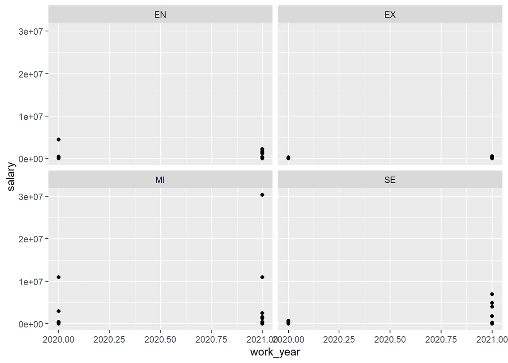

```r
ggplot(df, aes(x = work_year, y = salary)) +
  geom_point() +
  facet_wrap(~ experience_level)
```

These maps compare the work year to salary and experiences of the employees.

Make a plot using facet_wrap by two categorical variables (facet_wrap(~variable1+variable2))

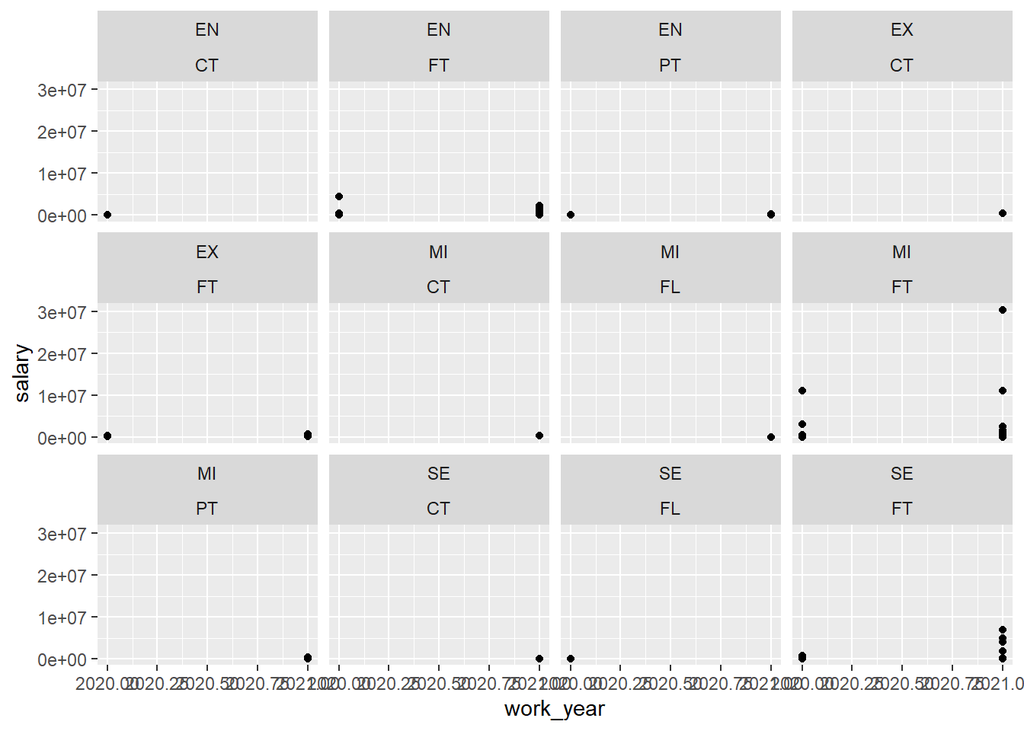

```r
ggplot(df, aes(x = work_year, y = salary)) +
  geom_point() +
  facet_wrap(~ experience_level + employment_type)
```

These maps compare the work year to salary and experiences of the employees as well as their employment type.

3. Make a plot using position =‘dodge’.

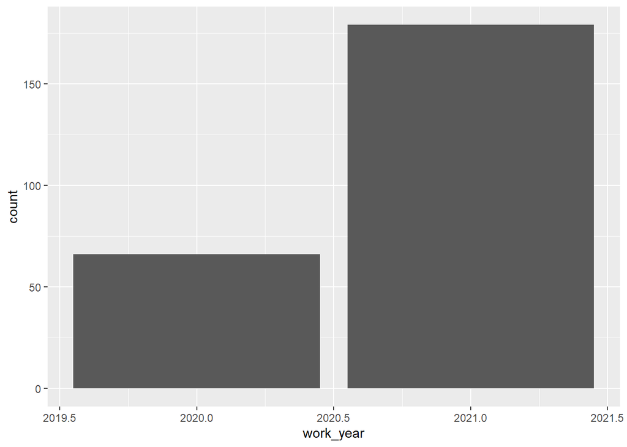

```r
df %>% ggplot()+
  geom_bar(mapping=aes(x = work_year , fill = remote_ratio),
           position = 'dodge')
```

Make a plot using position =‘fill’.

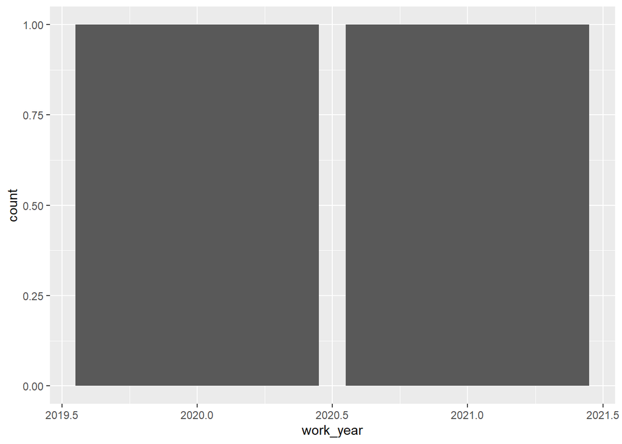

```r
df %>% ggplot()+
  geom_bar(mapping=aes(x = work_year , fill = remote_ratio),
           position = 'fill')
```

5. Make a plot using geom_col.

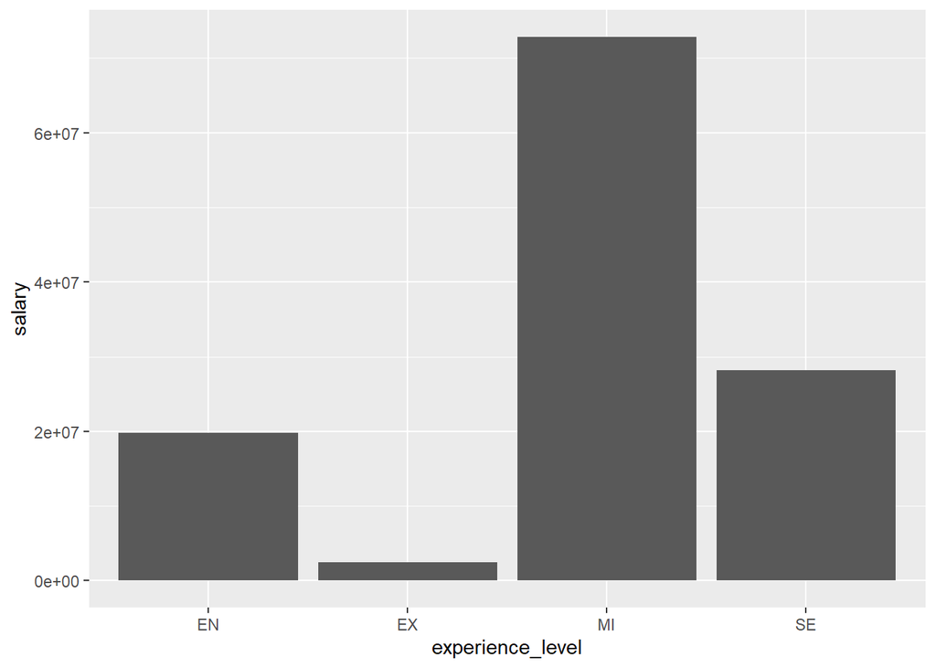

```r
df %>%
  ggplot()+
  geom_col(mapping=aes(x = experience_level, y = salary))
```

These bar graphs compare the experience level and the salary that the employment receives.

6. Change the theme of one of your plots.

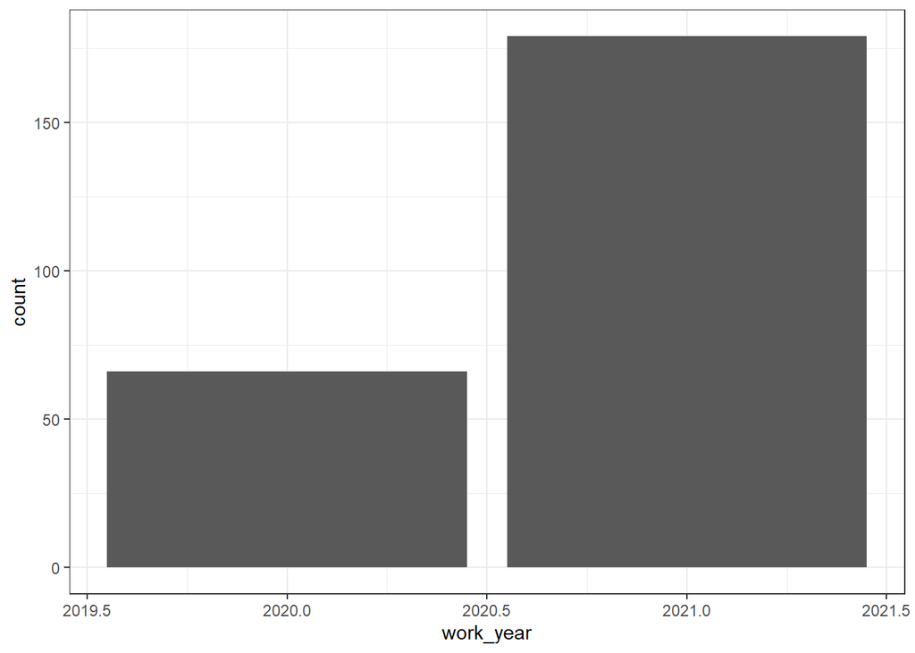

```r
df %>% ggplot()+
  geom_bar(mapping=aes(x = work_year , fill = remote_ratio))+
theme_bw()
```

7. Make a plot using combo filter + ggplot

```r
df %>%
  filter(work_year == 2020, remote_ratio == 0)
```

```
## # A tibble: 13 × 11
##    work_year experience_level employment_type job_title   salary salary_currency
##        <dbl> <chr>            <chr>           <chr>        <dbl> <chr>
##  1      2020 MI               FT              Research S… 4.50e5 USD
##  2      2020 MI               FT              Machine Le… 4.40e4 EUR
##  3      2020 EN               FT              Data Analy… 4.50e5 INR
##  4      2020 SE               FT              Data Engin… 7.20e5 MXN
##  5      2020 MI               FT              Lead Data … 1.15e5 USD
##  6      2020 SE               FT              Machine Le… 2.6 e5 USD
##  7      2020 MI               FT              Data Scien… 7   e4 EUR
##  8      2020 EN               FT              Data Scien… 4.50e4 EUR
##  9      2020 MI               FT              Data Scien… 3   e6 INR
## 10      2020 EN               FT              Data Scien… 3.5 e4 EUR
## 11      2020 MI               FT              Machine Le… 2.99e5 CNY
## 12      2020 MI               FT              BI Data An… 9.8 e4 USD
## 13      2020 SE               FT              Data Scien… 8   e4 EUR
## # ℹ 5 more variables: salary_in_usd <dbl>, employee_residence <chr>,
## #   remote_ratio <dbl>, company_location <chr>, company_size <chr>
```

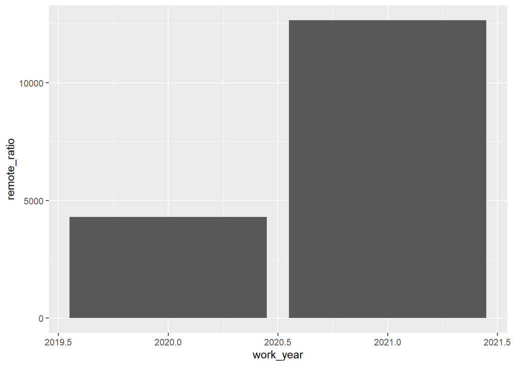

```r
  ggplot(df, aes(x = work_year, y = remote_ratio)) +
  geom_col()
```

8. Make a plot using combo group_by + summarise + geom_col

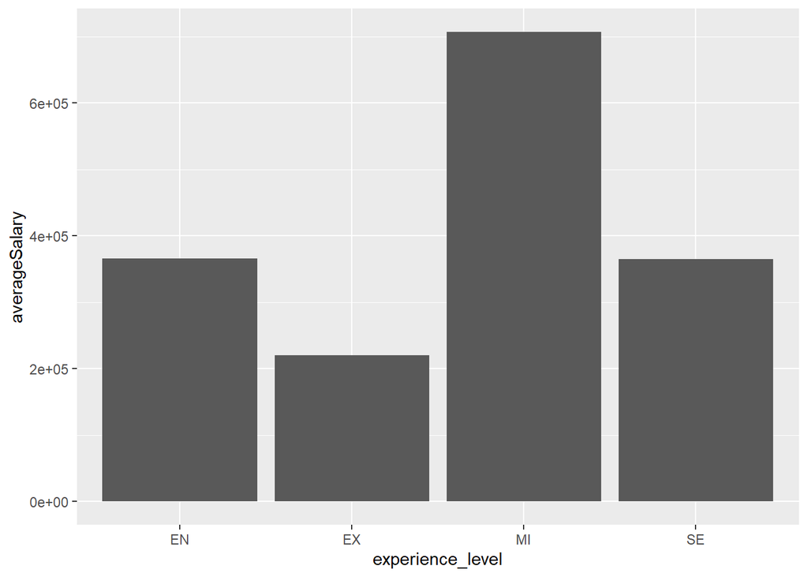

```r
df %>%
  group_by(experience_level) %>%
  summarise(averageSalary = mean(salary, na.rm=TRUE)) %>%
  ggplot()+
  geom_col(mapping=aes(x = experience_level, y = averageSalary))
```

These graphs show the average salary for each level of experience.

[output not shown]

Geom_point makes scatter plots, which plot two numeric (or Date) variables. A third categorical variable is often brought in for color. For example, we can compare different vaccine types used in the US by

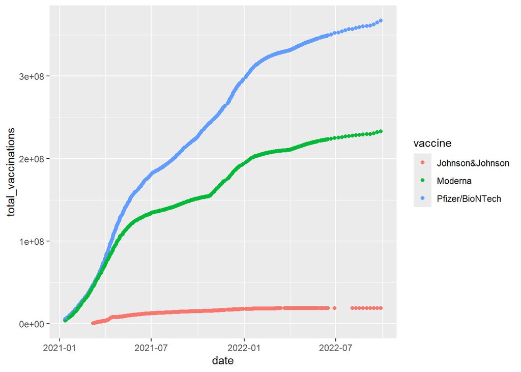

```r
df %>%
  filter(location=='United States') %>%
  ggplot()+
  geom_point(mapping = aes(x = date,
                                    y = total_vaccinations,
                                    color = vaccine))
```

Do the follows.

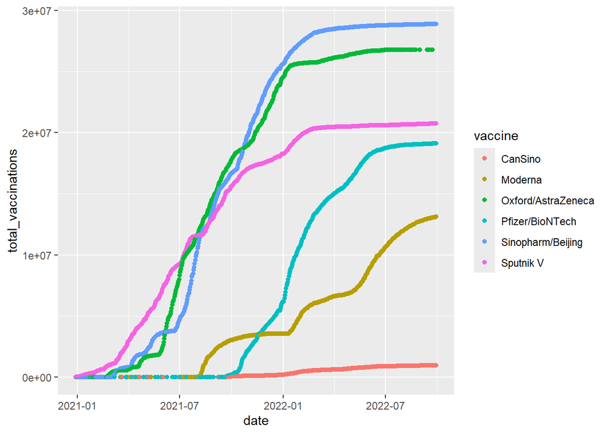

```r
df %>%
  group_by(date == 2022) %>%
  filter(location == 'Argentina') %>%
  ggplot()+
  geom_point(mapping = aes(x = date, y = total_vaccinations, color = vaccine))
```

Change geom_point to geom_line in the above codes to have the corresponding line plots.

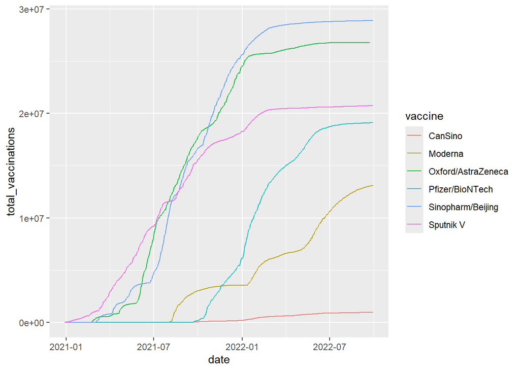

```r
df %>%
  group_by(date == 2022) %>%
  filter(location == 'Argentina') %>%
  ggplot()+
  geom_line(mapping = aes(x = date, y = total_vaccinations, color = vaccine))
```

11. (Using the same dataset as in 10.) Sometime we need to do some calculations on the data before plotting. For example, the below codes is to compare the total vaccines (including all types of vaccines) by date between the US and the EU

```r
d1 <- df %>%
  filter(location %in% c('United States', 'European Union')) %>%
  group_by(date, location) %>%
  summarise(total_vac2=sum(total_vaccinations, na.rm=TRUE))
```

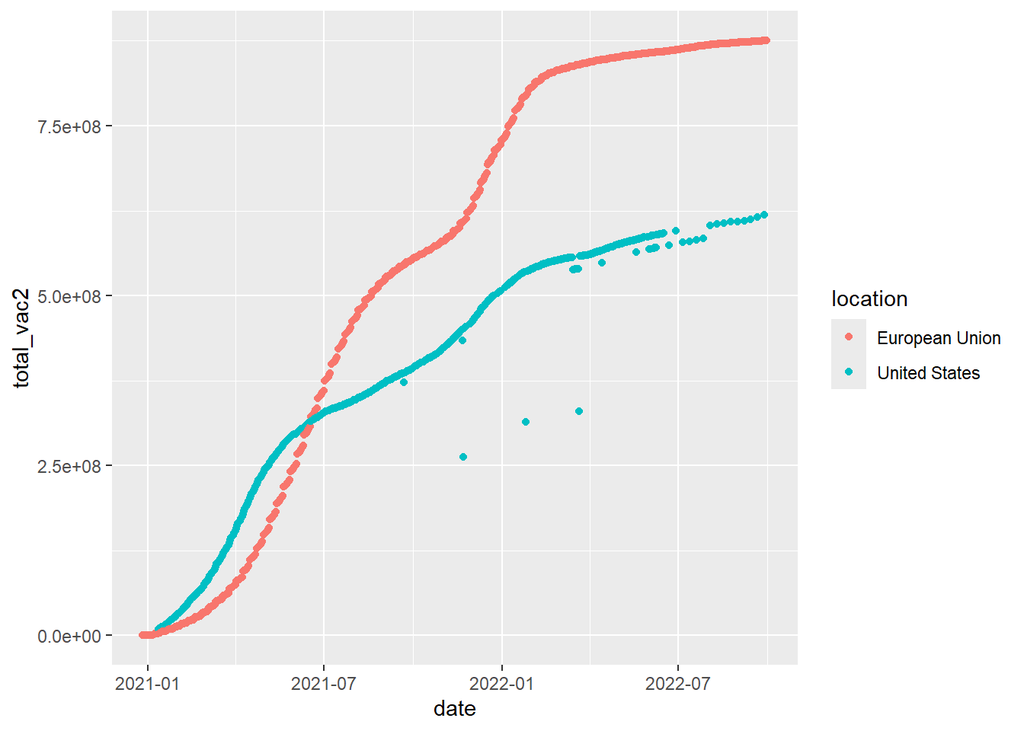

```r
# Plot
d1 %>%
  ggplot()+
  geom_point(mapping=aes(x=date, y=total_vac2, color=location))
```

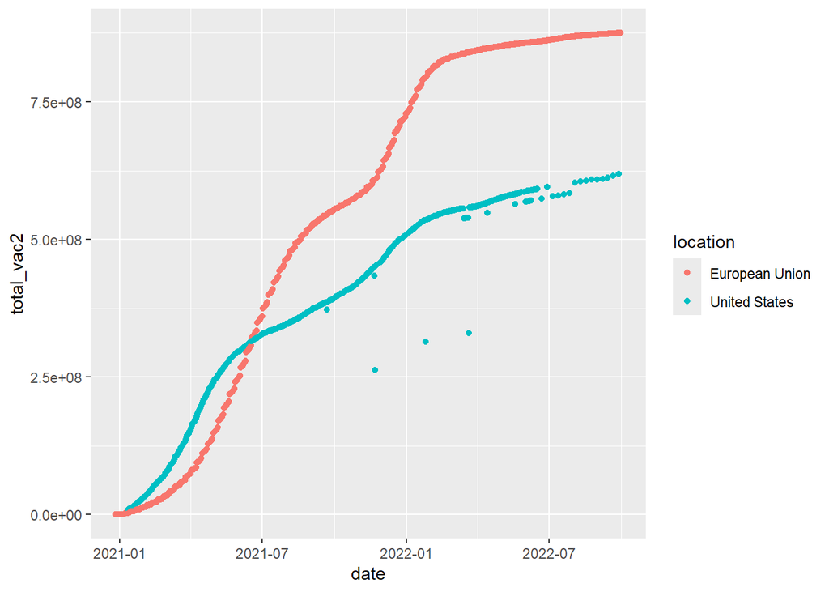

```r
df %>%
  filter(location %in% c('United States', 'European Union')) %>%
  group_by(date, location) %>%
  summarise(total_vac2=sum(total_vaccinations, na.rm=TRUE)) %>%
  ggplot()+
  geom_point(mapping=aes(x=date,
                         y=total_vac2,
                         color=location))
```

Do the follows.

Use geom_point compare the total vaccines (including all types of vaccines) by date between countries/regions in Asia

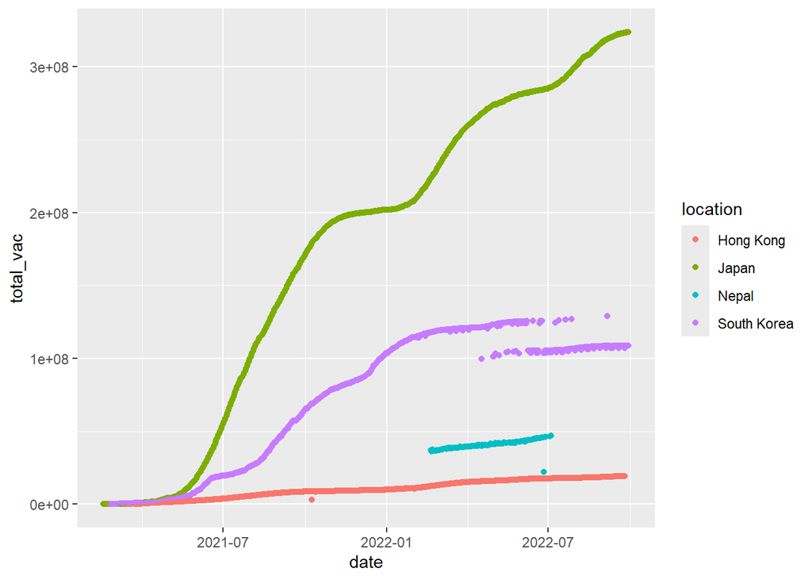

```r
df %>%
  filter(location %in% c('Hong Kong', 'Japan', 'South Korea', 'Nepal')) %>%
  group_by(date, location) %>%
  summarize(total_vac = sum(total_vaccinations, na.rm=TRUE)) %>%
  ggplot()+
  geom_point(mapping=aes(x = date, y = total_vac, color = location))
```

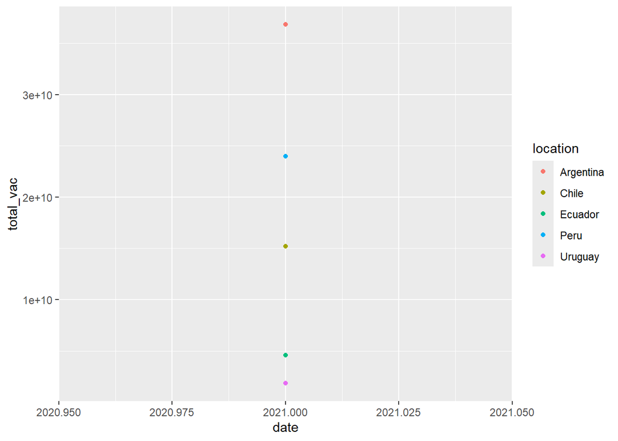

```r
df %>%
  filter(location %in% c('Argentina', 'Chile', 'Ecuador', 'Peru', 'Uruguay')) %>%
  group_by(date = 2021, location) %>%
  summarize(total_vac = sum(total_vaccinations, na.rm=TRUE)) %>%
  ggplot()+
  geom_point(mapping=aes(x = date, y = total_vac, color = location))
```